# Stochastic Growth Exercises 2

Ferran Estrella Serra

2026-06-23

## Part I– Deterministic Growth Component

```r
set.seed(123)
a0 <- 0.5
a1 <- 0.25
a2 <- -0.03
a3 <- 0.002
x0 <- 10

t0 <- 0
time_seq <- seq(0, 20, length.out = 500)
dt <- diff(time_seq)[1]
```

1. Implement the cubic polynomial

```r
Q <- function(t) {
  a0+a1*t+a2*t^2+a3*t^3
}
```

2. Compute the theoretical expected trajectory:

```r
theoretical_mean <- x0 * (1+exp(-Q(t0))) / (1+exp(-Q(time_seq)))
```

3. Plot the expected biomarker evolution over time.

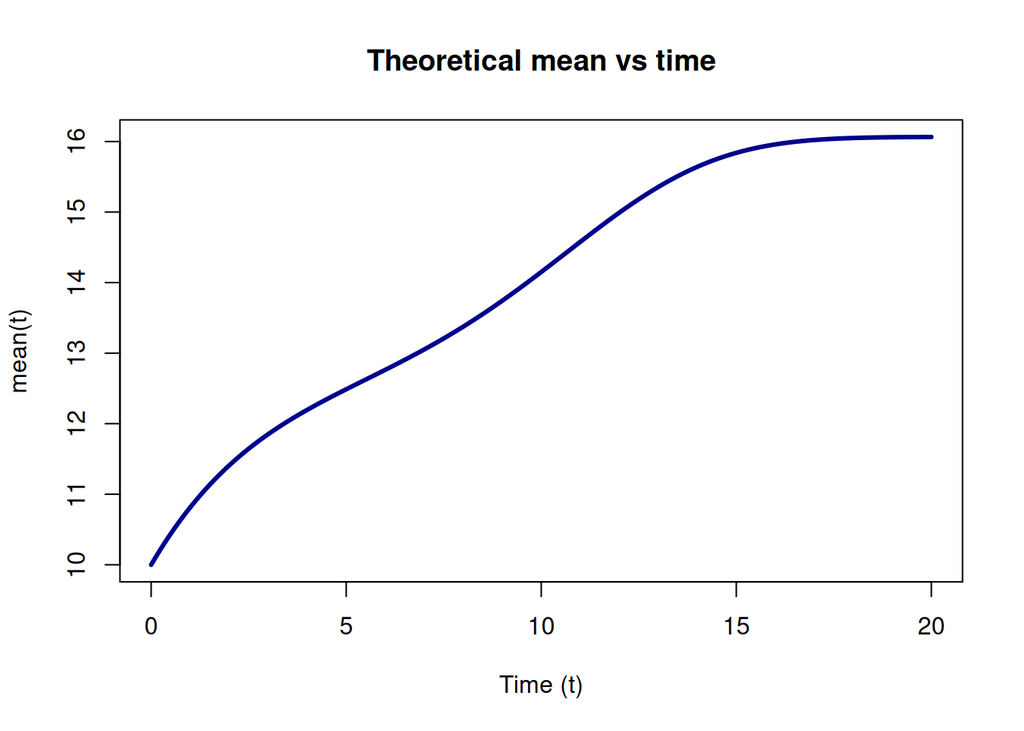

```r
plot(time_seq, theoretical_mean, type = 'l', col = 'darkblue', lwd = 3, , xlab = "Time (t)", ylab = "mean(t)",
     main = "Theoretical mean vs time")
```

## Part II– Simulation of the Diffusion Process

```r
sigma <- 0.25
M <- 200
N <- 500
```

1. Generate the 200 sample paths using the analytical solution (set.seed(123)).

```r
set.seed(123)
paths <- matrix(0, nrow = N, ncol = M)
for(j in 1:M) {
  dW <- rnorm(N - 1, mean = 0, sd = sqrt(dt)) # N-1 random increments for each N-1 intervals
  W  <- c(0, cumsum(dW)) # Cumulative sums of increments for each time step
  paths[, j] <- theoretical_mean * exp(-sigma^2/2*(time_seq-t0)+sigma*W)
}
```

2. Plot all trajectories in the same figure.
3. Overlay the theoretical mean trajectory.

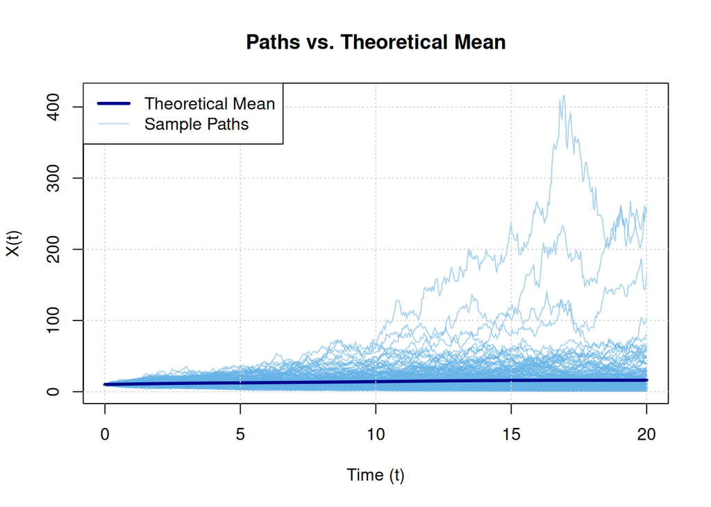

```r
plot(time_seq, theoretical_mean, type = 'l', col = 'darkblue', lwd = 3,
     ylim = c(0, max(paths)), xlab = "Time (t)", ylab = "X(t)",
     main = "Paths vs. Theoretical Mean")
matlines(time_seq, paths, type = 'l', lty = 1, col = rgb(0.4, 0.7, 0.9, 0.6))
lines(time_seq, theoretical_mean,
      col = "darkblue",
      lwd = 3)
grid()
legend("topleft", legend = c("Theoretical Mean", "Sample Paths"),
       col = c("darkblue", "lightblue"), lwd = c(3, 1))
```

Discuss:

- Do the stochastic trajectories follow the theoretical mean?

No, they do not. The variability of the stochastic process causes some paths to approach zero and remain below the theoretical mean most of the time, whereas other paths increase substantially due to volatility and end up taking much larger values than the theoretical mean over the considered time range. Some paths take very large values compared with the theoretical mean, but most paths take similar values.

- At which time periods is the variability larger?

We observe that the variability of the paths is larger at later times, since the stochastic noise accumulates at each time step. This causes some paths to take very large values in comparison with the theoretical mean.

## Part III– Predictive Uncertainty Using the Lognormal Distribution

Using the R function qlnorm(), compute: the 5% quantile; the 95% quantile.

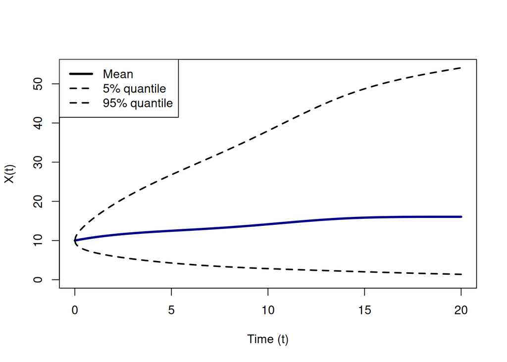

```r
mu_log <- log(x0) + log((1 + exp(-Q(t0))) / (1 + exp(-Q(time_seq)))) - (sigma^2 / 2) * (time_seq - t0)
sd_log <- sigma * sqrt(time_seq - t0)

q5 <- qlnorm(0.05, meanlog = mu_log, sdlog = sd_log)
q95 <- qlnorm(0.95, meanlog = mu_log, sdlog = sd_log)

plot(time_seq, theoretical_mean, type = "l", lwd = 3, col = "darkblue", ylim = c(0, max(q95)), xlab = "Time (t)", ylab = "X(t)")

lines(time_seq, q5,  lty = 2, lwd = 2)
lines(time_seq, q95, lty = 2, lwd = 2)

legend("topleft", legend = c("Mean", "5% quantile", "95% quantile"), lwd = c(3, 2, 2), lty = c(1, 2, 2))
```

1. Add a 90% uncertainty band to the trajectory plot.

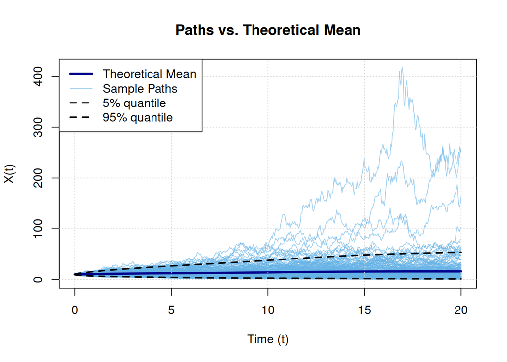

```r
plot(time_seq, theoretical_mean, type = 'l', col = 'darkblue', lwd = 3,
     ylim = c(0, max(paths)), xlab = "Time (t)", ylab = "X(t)",
     main = "Paths vs. Theoretical Mean")
matlines(time_seq, paths, type = 'l', lty = 1, col = rgb(0.4, 0.7, 0.9, 0.6))
lines(time_seq, theoretical_mean,
      col = "darkblue",
      lwd = 3)
grid()
lines(time_seq, q5,  lty = 2, lwd = 2)
lines(time_seq, q95, lty = 2, lwd = 2)

legend(
  "topleft",
  legend = c("Theoretical Mean", "Sample Paths", "5% quantile", "95% quantile"),
  col = c("darkblue", rgb(0.4, 0.7, 0.9, 0.6), "black", "black"),
  lwd = c(3, 1, 2, 2),
  lty = c(1, 1, 2, 2)
)
```

2. Compare: theoretical mean; simulated trajectories; prediction interval.

The theoretical mean lies inside the prediction interval, closer to the 5% quantile. We observe that a large number of paths lie within the prediction interval. The few trajectories below the 5% quantile, which are closer to zero, become more visible by setting ylim = 16 (for instance). The few trajectories above the 95% quantile are those that take significantly large values in comparison with the theoretical mean.

## Part IV– Statistical Interpretation

Question 1 How does increasing the volatility parameter from σ=0,25 to σ=0,60 affect the uncertainty of the process? Provide a mathematical explanation.

We can observe this increase in volatility by changing the value of σ, which we previously fixed at 0.25. In this case, we observe that some paths take even larger values (on the order of 10^3), the prediction interval becomes wider, and in particular the 95% quantile profile changes significantly.

As we increase the volatility parameter, we increase the amplitude of the white noise added to the growth rate over time. This leads to an increase in the uncertainty of the process, since the stochastic paths are driven by noise with higher variance (X(t) follows a lognormal with higher variance).

Question 2 Produce a figure comparing the two stochastic scenarios.

```r
set.seed(123)

N <- 500

sigma_vals <- c(0.25, 0.60)
M_vals <- c(6, 200)

results <- list()

for (m in M_vals) {
  for (sig in sigma_vals) {

    paths_tmp <- matrix(0, nrow = N, ncol = m)

    for (j in 1:m) {
      dW <- rnorm(N - 1, mean = 0, sd = sqrt(dt))
      W <- c(0, cumsum(dW))

      paths_tmp[, j] <- x0 * exp(- (sig^2 / 2) * time_seq +sig * W)
    }

    mu_log <- log(x0) - (sig^2 / 2) * time_seq
    sd_log <- sig * sqrt(time_seq)

    q5 <- qlnorm(0.05, meanlog = mu_log, sdlog = sd_log)
    q95 <- qlnorm(0.95, meanlog = mu_log, sdlog = sd_log)

    results[[paste0("M", m, "_s", sig)]] <- list(
      paths = paths_tmp,
      q5 = q5,
      q95 = q95,
      sigma = sig,
      M = m
    )
  }
}
```

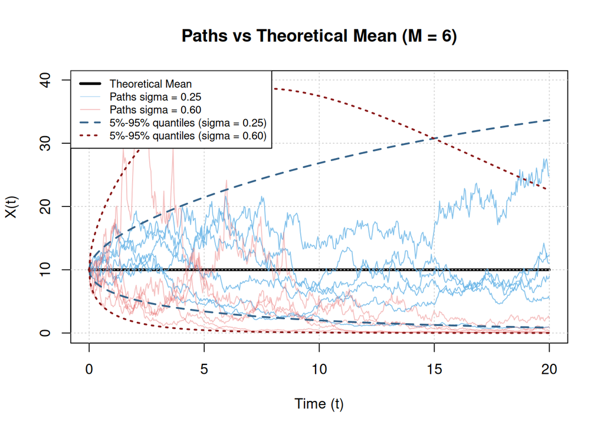

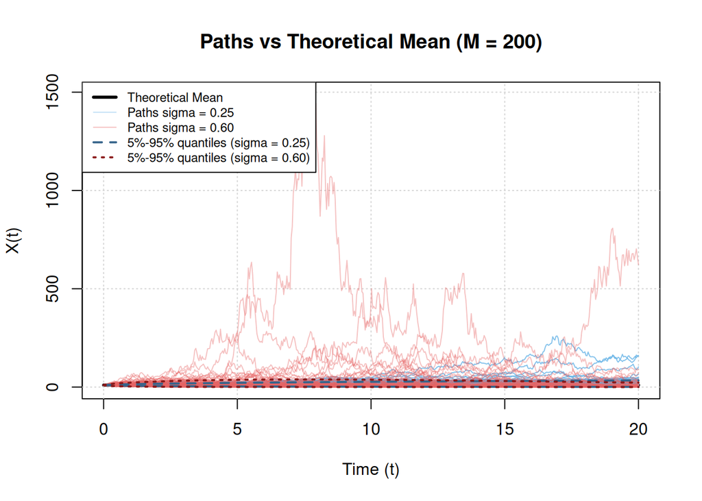

```r
for (m in M_vals) {

  # extract both cases for this M
  res1 <- results[[paste0("M", m, "_s0.25")]]
  res2 <- results[[paste0("M", m, "_s0.6")]]

  # paths
  paths1 <- res1$paths
  paths2 <- res2$paths

  # quantiles
  q5_1 <- res1$q5
  q95_1 <- res1$q95

  q5_2 <- res2$q5
  q95_2 <- res2$q95

  sigma1 <- res1$sigma
  sigma2 <- res2$sigma

  # theoretical mean (same for both)
  theoretical_mean <- x0 * exp(0 * time_seq)

  # plot
  plot(time_seq, theoretical_mean, type = "l",
       col = "black", lwd = 3,
       ylim = range(c(paths1, paths2, q5_1, q95_1, q5_2, q95_2), na.rm = TRUE),
       xlab = "Time (t)", ylab = "X(t)",
       main = sprintf("Paths vs Theoretical Mean (M = %d)", m)
  )

  grid()

  # paths
  matlines(time_seq, paths1, lty = 1,
           col = rgb(0.4, 0.7, 0.9, 0.8))

  matlines(time_seq, paths2, lty = 1,
           col = rgb(0.9, 0.4, 0.4, 0.4))

  # quantiles sigma 1
  lines(time_seq, q5_1,  lty = 2, lwd = 2, col = "steelblue4")
  lines(time_seq, q95_1, lty = 2, lwd = 2, col = "steelblue4")

  # quantiles sigma 2
  lines(time_seq, q5_2,  lty = 3, lwd = 2, col = "firebrick4")
  lines(time_seq, q95_2, lty = 3, lwd = 2, col = "firebrick4")

  # legend
  legend(
    "topleft",
    legend = c(
      "Theoretical Mean",
      sprintf("Paths sigma = %.2f", sigma1),
      sprintf("Paths sigma = %.2f", sigma2),
      sprintf("5%%-95%% quantiles (sigma = %.2f)", sigma1),
      sprintf("5%%-95%% quantiles (sigma = %.2f)", sigma2)
    ),
    col = c(
      "black",
      rgb(0.4, 0.7, 0.9, 0.4),
      rgb(0.9, 0.4, 0.4, 0.4),
      "steelblue4",
      "firebrick4"
    ),
    lwd = c(3, 1, 1, 2, 2),
    lty = c(1, 1, 1, 2, 3),
    cex = 0.75,
    text.font = 1
  )
}
```